# Mean Inference

David Gerbing

First read the Employee data included as part of **lessR**.

```r
d <- Read("Employee")
```

```
##
## >>> Suggestions
## Recommended binary format for data files: feather
##   Create with Write(d, "your_file", format="feather")
## More details about your data, Enter:  details()  for d, or  details(name)
##
## Data Types
## ------------------------------------------------------------
## character: Non-numeric data values
## integer: Numeric data values, integers only
## double: Numeric data values with decimal digits
## ------------------------------------------------------------
##
##     Variable                  Missing  Unique
##         Name     Type  Values  Values  Values   First and last values
## ------------------------------------------------------------------------------------------
##  1     Years   integer     36       1      16   7  NA  7 ... 1  2  10
##  2    Gender character     37       0       2   M  M  W ... W  W  M
##  3      Dept character     36       1       5   ADMN  SALE  FINC ... MKTG  SALE  FINC
##  4    Salary    double     37       0      37   53788.26  94494.58 ... 56508.32  57562.36
##  5    JobSat character     35       2       3   med  low  high ... high  low  high
##  6      Plan   integer     37       0       3   1  1  2 ... 2  2  1
##  7       Pre   integer     37       0      27   82  62  90 ... 83  59  80
##  8      Post   integer     37       0      22   92  74  86 ... 90  71  87
## ------------------------------------------------------------------------------------------
```

As an option, also read the table of variable labels. Create the table formatted as two columns. The first column is the variable name and the second column is the corresponding variable label. Not all variables need to be entered into the table. The table can be a `csv` file or an Excel file.

Currently, read the label file into the *l* data frame. The labels are displayed on both the text and visualization output. Each displayed label consists of the variable name juxtaposed with the corresponding label.

```r
l <- rd("Employee_lbl")
```

```
##
## >>> Suggestions
## Recommended binary format for data files: feather
##   Create with Write(d, "your_file", format="feather")
## More details about your data, Enter:  details()  for d, or  details(name)
##
## Data Types
## ------------------------------------------------------------
## character: Non-numeric data values
## ------------------------------------------------------------
##
##     Variable                  Missing  Unique
##         Name     Type  Values  Values  Values   First and last values
## ------------------------------------------------------------------------------------------
##  1     label character      8       0       8   Time of Company Employment ... Test score on legal issues after instruction
## ------------------------------------------------------------------------------------------
```

## One-Sample t-test

Obtain the summary statistics and 95% confidence interval for a single variable by specifying that variable with `ttest()`. Because *d* is the default name of the data frame that contains the variables for analysis, the `data` parameter that names the input data frame need not be specified.

```r
ttest(Salary)
```

```
##
## Response Variable:  Salary, Annual Salary (USD)
##
##
## ------ Describe ------
##
## Salary:  n.miss = 0,  n = 37,   mean = 73795.557,  sd = 21799.533
##
##
## ------ Normality Assumption ------
##
## Sample mean assumed normal because n > 30, so no test needed.
##
##
## ------ Infer ------
##
## t-cutoff for 95% range of variation: tcut =  2.028
## Standard Error of Mean: SE =  3583.821
##
## Margin of Error for 95% Confidence Level:  7268.326
## 95% Confidence Interval for Mean:  66527.230 to 81063.883
```

Add a hypothesis test to the above.

```r
ttest(Salary, mu=52000)
```

```
##
## Response Variable:  Salary, Annual Salary (USD)
##
##
## ------ Describe ------
##
## Salary:  n.miss = 0,  n = 37,   mean = 73795.557,  sd = 21799.533
##
##
## ------ Normality Assumption ------
##
## Sample mean assumed normal because n > 30, so no test needed.
##
##
## ------ Infer ------
##
## t-cutoff for 95% range of variation: tcut =  2.028
## Standard Error of Mean: SE =  3583.821
##
## Hypothesized Value H0: mu = 52000
## Hypothesis Test of Mean:  t-value = 6.082,  df = 36,  p-value = 0.000
##
## Margin of Error for 95% Confidence Level:  7268.326
## 95% Confidence Interval for Mean:  66527.230 to 81063.883
##
##
## ------ Effect Size ------
##
## Distance of sample mean from hypothesized:  21795.557
## Standardized Distance, Cohen's d:  1.000
##
##
## ------ Graphics Smoothing Parameter ------
##
## Density bandwidth for 12035.673
```

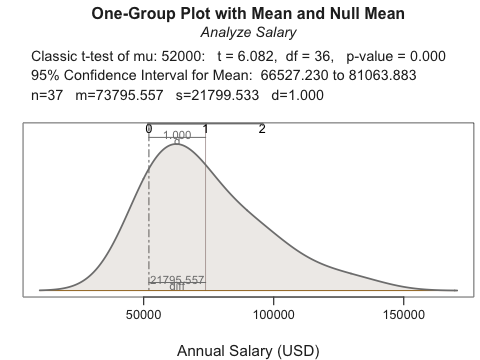

Analysis of the above from summary statistics only.

```r
ttest(n=37, m=73795.557, s=21799.533, Ynm="Salary", mu=52000)
```

```
##
## Response Variable:  Salary, Annual Salary (USD)
##
##
## ------ Describe ------
##
## Salary: n = 37,   mean = 73795.56,  sd = 21799.53
##
##
## ------ Infer ------
##
## t-cutoff for 95% range of variation: tcut =  2.028
## Standard Error of Mean: SE =  3583.821
##
## Hypothesized Value H0: mu = 52000
## Hypothesis Test of Mean:  t-value = 6.082,  df = 36,  p-value = 0.000
##
## Margin of Error for 95% Confidence Level:  7268.326
## 95% Confidence Interval for Mean:  66527.231 to 81063.883
##
##
## ------ Effect Size ------
##
## Distance of sample mean from hypothesized:  21795.557
## Standardized Distance, Cohen's d:  1.000
```

## Two-Samples t-test

### Independent Groups

Full analysis with `ttest()` function, abbreviated as `tt()`, with formula mode.

```r
ttest(Salary ~ Gender)
```

```
##
## Compare Salary across Gender with levels M and W
## Response Variable:  Salary, Annual Salary (USD)
## Grouping Variable:  Gender, Man or Woman
##
##
## ------ Describe ------
##
## Salary for Gender M:  n.miss = 0,  n = 18,  mean = 81147.458,  sd = 23128.436
## Salary for Gender W:  n.miss = 0,  n = 19,  mean = 66830.598,  sd = 18438.456
##
## Mean Difference of Salary:  14316.860
##
## Weighted Average Standard Deviation:   20848.636
##
##
## ------ Assumptions ------
##
## Note: These hypothesis tests can perform poorly, and the
##       t-test is typically robust to violations of assumptions.
##       Use as heuristic guides instead of interpreting literally.
##
## Null hypothesis, for each group, is a normal distribution of Salary.
## Group M  Shapiro-Wilk normality test:  W = 0.962,  p-value = 0.647
## Group W  Shapiro-Wilk normality test:  W = 0.828,  p-value = 0.003
##
## Null hypothesis is equal variances of Salary, homogeneous.
## Variance Ratio test:  F = 534924536.348/339976675.129 = 1.573,  df = 17;18,  p-value = 0.349
## Levene's test, Brown-Forsythe:  t = 1.302,  df = 35,  p-value = 0.201
##
##
## ------ Infer ------
##
## --- Assume equal population variances of Salary for each Gender
##
## t-cutoff for 95% range of variation: tcut =  2.030
## Standard Error of Mean Difference: SE =  6857.494
##
## Hypothesis Test of 0 Mean Diff:  t-value = 2.088,  df = 35,  p-value = 0.044
##
```

[output cut: 18 more lines]

```
##
## Standardized Mean Difference of Salary, Cohen's d:  0.687
##
##
## ------ Practical Importance ------
##
## Minimum Mean Difference of practical importance: mmd
## Minimum Standardized Mean Difference of practical importance: msmd
## Neither value specified, so no analysis
##
##
## ------ Graphics Smoothing Parameter ------
##
## Density bandwidth for Gender M: 14777.329
## Density bandwidth for Gender W: 11630.959
```

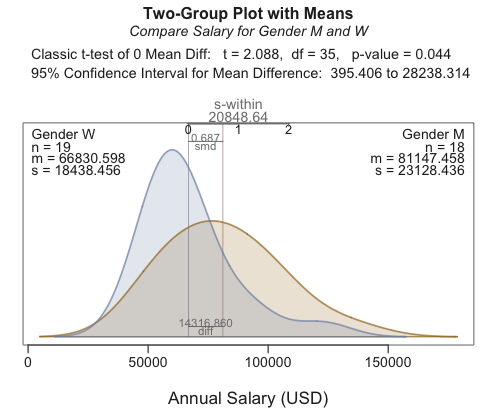

Brief version of the output contains just the basics.

```r
tt_brief(Salary ~ Gender)
```

```
##
## Compare Salary across Gender with levels M and W
## Response Variable:  Salary, Annual Salary (USD)
## Grouping Variable:  Gender, Man or Woman
##
##
##  --- Describe ---
##
## Salary for Gender M:  n.miss = 0,  n = 18,  mean = 81147.458,  sd = 23128.436
## Salary for Gender W:  n.miss = 0,  n = 19,  mean = 66830.598,  sd = 18438.456
##
## Mean Difference of Salary:  14316.860
## Weighted Average Standard Deviation:   20848.636
## Standardized Mean Difference of Salary: 0.687
##
##  --- Infer ---
##
## t-cutoff for 95% range of variation: tcut =  2.030
## Standard Error of Mean Difference: SE =  6857.494
##
## Hypothesis Test of 0 Mean Diff:  t-value = 2.088,  df = 35,  p-value = 0.044
##
## Margin of Error for 95% Confidence Level:  13921.454
## 95% Confidence Interval for Mean Difference:  395.406 to 28238.314
```

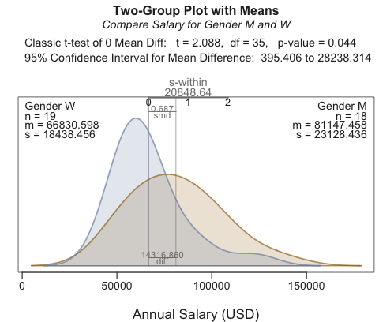

### Dependent Groups

```r
tt_brief(Pre, Post)
```

```
##
## Compare Y across X with levels Group2 and Group1
## Response Variable:  Y, Y
## Grouping Variable:  X,
##
##
##  --- Describe ---
##
## Y for X Group2:  n.miss = 0,  n = 37,  mean = 81.000,  sd = 11.593
## Y for X Group1:  n.miss = 0,  n = 37,  mean = 78.784,  sd = 12.037
##
## Mean Difference of Y:  2.216
## Weighted Average Standard Deviation:   11.817
## Standardized Mean Difference of Y: 0.188
##
##  --- Infer ---
##
## t-cutoff for 95% range of variation: tcut =  1.993
## Standard Error of Mean Difference: SE =  2.747
##
## Hypothesis Test of 0 Mean Diff:  t-value = 0.807,  df = 72,  p-value = 0.423
##
## Margin of Error for 95% Confidence Level:  5.477
## 95% Confidence Interval for Mean Difference:  -3.261 to 7.693
```

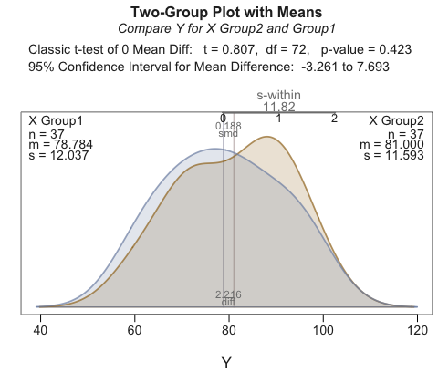

## ANOVA

Analysis of variance applies to the inferential analysis of means across groups. The **lessR** function `ANOVA()`, abbreviated `av()`, provides this analysis, based on the base R function `aov()`.

The data for these examples is the *warpbreaks* data set included with the R **datasets** package. The data are from a weaving device called a loom for a fixed length of yarn. The response variable is the number of times the yarn broke during the weaving. Independent variables are the type of wool – A or B –and the level of tension – L, M, or H.

Because *warpbreaks* is not the default data frame, specify with the `data` parameter (or set *d* equal to *warpbreaks*).

### One-way Independent Groups

First, for illustrative purposes, ignore the type of wool and only examine the impact of tension on breaks.

The output includes descriptive statistics, ANOVA table, effect size indices, Tukey’s multiple comparisons of means, and residuals, as well as the scatterplot of the response variable with the levels of the independent variable, and a visualization of the mean comparisons.

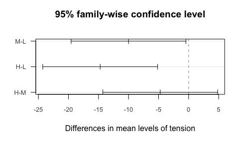

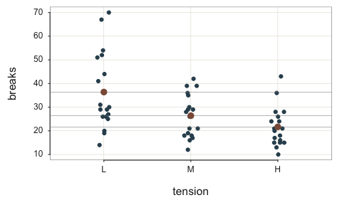

```
##
##   BACKGROUND
##
## Response Variable: breaks
##
## Factor Variable: tension
##   Levels: L M H
##
## Number of cases (rows) of data:  54
## Number of cases retained for analysis:  54
##
##
##   DESCRIPTIVE STATISTICS
##
##     n    mean      sd     min     max
## L  18   36.39   16.45   14.00   70.00
## M  18   26.39    9.12   12.00   42.00
## H  18   21.67    8.35   10.00   43.00
##
## Grand Mean: 28.148
##
##
##   ANOVA
##
##              df    Sum Sq   Mean Sq   F-value   p-value
## tension       2   2034.26   1017.13      7.21    0.0018
## Residuals    51   7198.56    141.15
##
## R Squared: 0.220
## R Sq Adjusted: 0.190
## Omega Squared: 0.187
##
##
## Cohen's f: 0.479
##
##
##   TUKEY MULTIPLE COMPARISONS OF MEANS
##
## Family-wise Confidence Level: 0.95
## -------------------------------
```

[output cut: 23 more lines]

```
##   14       M  12.00  26.39   -14.39   -1.25
##   19       H  36.00  21.67    14.33    1.24
##   41       M  39.00  26.39    12.61    1.09
##   44       M  39.00  26.39    12.61    1.09
##   23       H  10.00  21.67   -11.67   -1.01
##    4       L  25.00  36.39   -11.39   -0.99
##    8       L  26.00  36.39   -10.39   -0.90
##   40       M  16.00  26.39   -10.39   -0.90
##    1       L  26.00  36.39   -10.39   -0.90
##   18       M  36.00  26.39     9.61    0.83
##
## ----------------------------------------
## Plot 1: 95% family-wise confidence level
## Plot 2: Scatterplot with Cell Means
## ----------------------------------------
```

```r
ANOVA(breaks ~ tension, data=warpbreaks)
```

The brief version forgoes the multiple comparisons and the residuals.

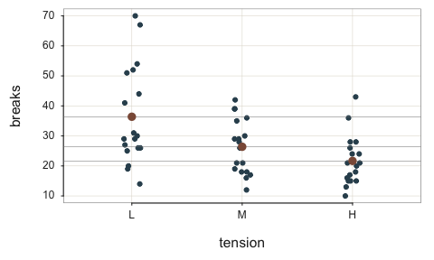

```
##
##   BACKGROUND
##
## Response Variable: breaks
##
## Factor Variable: tension
##   Levels: L M H
##
## Number of cases (rows) of data:  54
## Number of cases retained for analysis:  54
##
##
##   DESCRIPTIVE STATISTICS
##
##     n    mean      sd     min     max
## L  18   36.39   16.45   14.00   70.00
## M  18   26.39    9.12   12.00   42.00
## H  18   21.67    8.35   10.00   43.00
##
## Grand Mean: 28.148
##
##
##   ANOVA
##
##              df    Sum Sq   Mean Sq   F-value   p-value
## tension       2   2034.26   1017.13      7.21    0.0018
## Residuals    51   7198.56    141.15
##
## R Squared: 0.220
## R Sq Adjusted: 0.190
## Omega Squared: 0.187
##
##
## Cohen's f: 0.479
##
##
##   TUKEY MULTIPLE COMPARISONS OF MEANS
##
##
##   RESIDUALS
```

```r
av_brief(breaks ~ tension, data=warpbreaks)
```

### Two-way Independent Groups

Specify the second independent variable preceded by a `*` sign. The plot of the cell means is generated automatically.

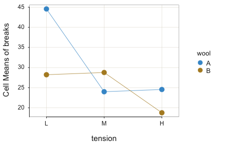

```
##
##   BACKGROUND
##
## Response Variable: breaks
##
## Factor Variable 1: tension
##   Levels: L M H
##
## Factor Variable 2: wool
##   Levels: A B
##
## Number of cases (rows) of data:  54
## Number of cases retained for analysis:  54
##
## Two-way Between Groups ANOVA
##
##
##   DESCRIPTIVE STATISTICS
##
##
## Equal cell sizes, so balanced design
##
##
##       tension
##  wool    L    M    H
##     A    9    9    9
##     B    9    9    9
##
##
##       tension
##  wool     L     M     H
##     A 44.56 24.00 24.56
##     B 28.22 28.78 18.78
##
## tension
##
##         L     M     H
##   1 36.39 26.39 21.67
##
## wool
```

[output cut: 80 more lines]

```
##   24       H    A  43.00  24.56    18.44    1.79
##   36       L    B  44.00  28.22    15.78    1.53
##    2       L    A  30.00  44.56   -14.56   -1.41
##   23       H    A  10.00  24.56   -14.56   -1.41
##   29       L    B  14.00  28.22   -14.22   -1.38
##   37       M    B  42.00  28.78    13.22    1.28
##   34       L    B  41.00  28.22    12.78    1.24
##   40       M    B  16.00  28.78   -12.78   -1.24
##   14       M    A  12.00  24.00   -12.00   -1.16
##   18       M    A  36.00  24.00    12.00    1.16
##   19       H    A  36.00  24.56    11.44    1.11
##   16       M    A  35.00  24.00    11.00    1.07
##   41       M    B  39.00  28.78    10.22    0.99
##   44       M    B  39.00  28.78    10.22    0.99
##   39       M    B  19.00  28.78    -9.78   -0.95
```

```r
ANOVA(breaks ~ tension * wool, data=warpbreaks)
```

Can also obtain the cell mean plot directly from the means. Here use **lessR** `pivot()` to compute the cell means of *breaks* across *tension* and *wool*.

```r
data(warpbreaks)
dm <- pivot(warpbreaks, mean, breaks, c(tension, wool))
dm
```

```
##   tension wool breaks_n breaks_na breaks_mean
## 1       L    A        9         0      44.556
## 2       M    A        9         0      24.000
## 3       H    A        9         0      24.556
## 4       L    B        9         0      28.222
## 5       M    B        9         0      28.778
## 6       H    B        9         0      18.778
```

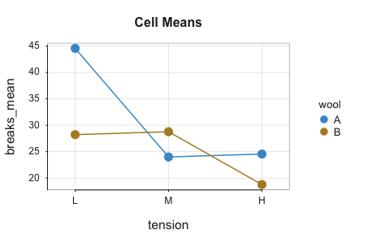

```
## breaks_mean
##   - by levels of -
## tension
##
##     n   miss        mean          sd         min         mdn         max
## L   2      0     36.3890     11.5499     28.2220     36.3890     44.5560
## M   2      0     26.3890      3.3786     24.0000     26.3890     28.7780
## H   2      0     21.6670      4.0857     18.7780     21.6670     24.5560
##
## Some Parameter values (can be manually set)
## -------------------------------------------------------
## size: 1.60  size of plotted points
## jitter_y: 0.00  random vertical movement of points
## jitter_x: 0.00  random horizontal movement of points
```

```r
Plot(tension, breaks_mean, by=wool, segments=TRUE, size=2, data=dm,
     main="Cell Means")
```

### Randomized Block Design

The randomized block design has a treatment variable, usually administered over time, and a blocking variable. The values of the treatment variable are measured across each instance of the blocking variable. In this example, repetitions are measured across four different workout sessions. The person takes one of four supplements before each session. Person is the blocking variable, and Supplement is the treatment variable. Repetitions is the response variable.

The data are presented in a wide-form data table, a single row for each person.

```r
d <- read.csv(header=TRUE, text="
Person,sup1,sup2,sup3,sup4
p1,2,4,4,3
p2,2,5,4,6
p3,8,6,7,9
p4,4,3,5,7
p5,2,1,2,3
p6,5,5,6,8
p7,2,3,2,4")
```

The ANOVA, however, requires data to be in long-form. Reshape data from wide form to long form with base R `reshape()` according to the following parameters. With each parameter, either *identify* existing variables in the given wide-form data, or *name* newly created variables in the long-form. This R function refers to a time-variable, which in the context of ANOVA is the treatment variable, of which the values occur over time: first treatment, second treatment, etc.

- `idvar`: Identify the existing blocking (within) variable in the wide-form data
- `varying`: Identify the wide-form variables, which occur over time, to be gathered into a single variable in long-format
- `timevar`: Name the corresponding treatment (factor) variable in the created long-form
- `v.names`: Name the response variable in the created long-form

There are many ways to identify the names of the wide-form variables to be gathered into a single time-oriented long-form variable. The most general is to specify a vector of the names, here

```
c("sup1", "sup2" "sup3", "sup4")
```

In this example use the **lessR** `to` function to create that vector without needed to individually list each variable.

```r
to("sup", 4)
```

```
## [1] "sup1" "sup2" "sup3" "sup4"
```

```r
d <- reshape(d, direction="long",
        idvar="Person", varying=list(to("sup", 4)),
        timevar="Supplement", v.names="Reps")
```

Do not need the row names, so remove before displaying new long-form data.

```r
row.names(d) <- NULL
d[1:10,]
```

```
##    Person Supplement Reps
## 1      p1          1    2
## 2      p2          1    2
## 3      p3          1    8
## 4      p4          1    4
## 5      p5          1    2
## 6      p6          1    5
## 7      p7          1    2
## 8      p1          2    4
## 9      p2          2    5
## 10     p3          2    6
```

To run the ANOVA, specify the blocking variable preceded by a `+` sign.

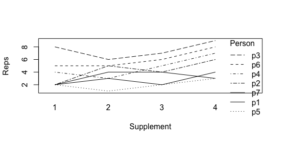

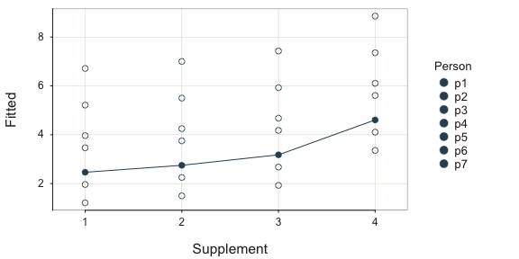

```
##
##   BACKGROUND
##
## Response Variable: Reps
##
## Factor Variable 1: Supplement
##   Levels: 1 2 3 4
##
## Factor Variable 2: Person
##   Levels: p1 p2 p3 p4 p5 p6 p7
##
## Number of cases (rows) of data:  28
## Number of cases retained for analysis:  28
##
## Randomized Blocks ANOVA
##   Factor of Interest:  Supplement
##   Blocking Factor:     Person
##
## Note: For the resulting F statistic for Supplement to be distributed as F,
##       the population covariances of Reps must be spherical.
##
##
##   DESCRIPTIVE STATISTICS
##
## Supplement
##
##       X1   X2   X3   X4
##   1 3.57 3.86 4.29 5.71
##
## Person
##
##       p1   p2   p3   p4   p5   p6   p7
##   1 3.25 4.25 7.50 4.75 2.00 6.00 2.75
##
## NA
##
##
##
##   ANOVA
##
```

[output cut: 45 more lines]

```
##   14          2     p7    3   2.25     0.75    0.96
##   21          3     p7    2   2.68    -0.68   -0.87
##   27          4     p6    8   7.36     0.64    0.83
##   12          2     p5    1   1.50    -0.50   -0.64
##   13          2     p6    5   5.50    -0.50   -0.64
##    1          1     p1    2   2.46    -0.46   -0.60
##   17          3     p3    7   7.43    -0.43   -0.55
##   23          4     p2    6   5.61     0.39    0.50
##   26          4     p5    3   3.36    -0.36   -0.46
##   18          3     p4    5   4.68     0.32    0.41
##
## ---------------------
## Plot 1: Data Values
## Plot 2: Fitted Values
## ---------------------
```

```r
ANOVA(Reps ~ Supplement + Person)
```

## Full Manual

Use the base R `help()` function to view the full manual for `ttest()` or `ANOVA()`. Simply enter a question mark followed by the name of the function.

```
?ttest
?ANOVA
```